# PROJET 4 DATA ANALYST

## Réalisez une étude de santé publique avec R ou Python

# OBJECTIF DE CE NOTEBOOK

Bienvenue dans l'outil plébiscité par les analystes de données Jupyter.

Il s'agit d'un outil permettant de mixer et d'alterner codes, textes et graphique.

Cet outil est formidable pour plusieurs raisons:

- il permet de tester des lignes de codes au fur et à mesure de votre rédaction, de constater immédiatement le résultat d'un instruction, de la corriger si nécessaire.
- De rédiger du texte pour expliquer l'approche suivie ou les résultats d'une analyse et de le mettre en forme grâce à du code html ou plus simple avec **Markdown**
- d'agrémenter de graphiques

Pour vous aider dans vos premiers pas à l'usage de Jupyter et de Python, nous avons rédigé ce notebook en vous indiquant les instructions à suivre.

Il vous suffit pour cela de saisir le code Python répondant à l'instruction donnée.

Vous verrez de temps à autre le code Python répondant à une instruction donnée mais cela est fait pour vous aider à comprendre la nature du travail qui vous est demandée.

Et garder à l'esprit, qu'il n'y a pas de solution unique pour résoudre un problème et qu'il y a autant de résolutions de problèmes que de développeurs ;)...

## Etape 1 - Importation des librairies et chargement des fichiers

### 1.1 - Importation des librairies

```python
#Importation de la librairie Pandas
import pandas as pd #  Importation de la librairie Pandas
import numpy as np # Importation de la librairie Numpy
import matplotlib.pyplot as plt # Importation de la librairie Matplotlib pour les graphiques
import seaborn as sns # Importation de la librairie Seaborn pour les graphiques
```

### 1.2 - Chargement des fichiers Excel

```python
#Importation du fichier population.csv
population = pd.read_csv('population.csv')

#Importation du fichier dispo_alimentaire.csv
dispo_alimentaire= pd.read_csv('dispo_alimentaire.csv')

#Importation du fichier aide_alimentaire.csv
aide_alimentaire = pd.read_csv('aide_alimentaire.csv')

#Importation du fichier sous_nutrition.csv
sous_nutrition = pd.read_csv('sous_nutrition.csv')
```

## Etape 2 - Analyse exploratoire des fichiers

### 2.1 - Analyse exploratoire du fichier population

```python
#Afficher les dimensions du dataset
print("Le tableau comporte {} observation(s) ou article(s)".format(population.shape[0]))
print("Le tableau comporte {} colonne(s)".format(population.shape[1]))
```

```
Le tableau comporte 1416 observation(s) ou article(s)
Le tableau comporte 3 colonne(s)
```

```python
#Consulter le nombre de colonnes
print("nombre de colonnes:", population.info())
#La nature des données dans chacune des colonnes
print("Nature des données dans chacune des colonnes:", population.dtypes)
#Le nombre de valeurs présentes dans chacune des colonnes
print("Nombre de valeurs présentes dans chacune des colonnes:", population.count())
```

```
<class 'pandas.core.frame.DataFrame'>
RangeIndex: 1416 entries, 0 to 1415
Data columns (total 3 columns):
 #   Column  Non-Null Count  Dtype
---  ------  --------------  -----
 0   Zone    1416 non-null   object
 1   Année   1416 non-null   int64
 2   Valeur  1416 non-null   float64
dtypes: float64(1), int64(1), object(1)
memory usage: 33.3+ KB
nombre de colonnes: None
Nature des données dans chacune des colonnes: Zone       object
Année       int64
Valeur    float64
dtype: object
Nombre de valeurs présentes dans chacune des colonnes: Zone      1416
Année     1416
Valeur    1416
dtype: int64
```

```python
#Affichage les 5 premières lignes de la table
population.head()
```

|  | Zone | Année | Valeur |
| --- | --- | --- | --- |
| 0 | Afghanistan | 2013 | 32269.589 |
| 1 | Afghanistan | 2014 | 33370.794 |
| 2 | Afghanistan | 2015 | 34413.603 |
| 3 | Afghanistan | 2016 | 35383.032 |
| 4 | Afghanistan | 2017 | 36296.113 |

```python
#Nous allons harmoniser les unités. Pour cela, nous avons décidé de multiplier la population par 1000
#Multiplication de la colonne valeur par 1000

population['Valeur'] = population['Valeur'] * 1000
population.head()
```

|  | Zone | Année | Valeur |
| --- | --- | --- | --- |
| 0 | Afghanistan | 2013 | 32269589.0 |
| 1 | Afghanistan | 2014 | 33370794.0 |
| 2 | Afghanistan | 2015 | 34413603.0 |
| 3 | Afghanistan | 2016 | 35383032.0 |
| 4 | Afghanistan | 2017 | 36296113.0 |

```python
#changement du nom de la colonne Valeur par Population
population.rename(columns={'Valeur': 'Population'}, inplace=True)
```

```python
#Affichage les 5 premières lignes de la table pour voir les modifications
population.head()
```

|  | Zone | Année | Population |
| --- | --- | --- | --- |
| 0 | Afghanistan | 2013 | 32269589.0 |
| 1 | Afghanistan | 2014 | 33370794.0 |
| 2 | Afghanistan | 2015 | 34413603.0 |
| 3 | Afghanistan | 2016 | 35383032.0 |
| 4 | Afghanistan | 2017 | 36296113.0 |

### 2.2 - Analyse exploratoire du fichier disponibilité alimentaire

```python
#Afficher les dimensions du dataset
print("le tableau comporta {} observations" .format(dispo_alimentaire.shape[0]))
print("le tableau comporta {} colonnes" .format(dispo_alimentaire.shape[1]))
```

```
le tableau comporta 15605 observations
le tableau comporta 18 colonnes
```

```python
#Consulter le nombre de colonnes
print("nombre de colonnes:", dispo_alimentaire.info())
#La nature des données dans chacune des colonnes
print("Nature des donnees dans chacune des colonnes:", dispo_alimentaire.dtypes)
#Le nombre de valeurs présentes dans chacune des colonnes
print("Nombre de valeurs présentes dans chacune des colonnes:", dispo_alimentaire.count())
```

```
<class 'pandas.core.frame.DataFrame'>
RangeIndex: 15605 entries, 0 to 15604
Data columns (total 18 columns):
 #   Column                                                         Non-Null Count  Dtype
---  ------                                                         --------------  -----
 0   Zone                                                           15605 non-null  object
 1   Produit                                                        15605 non-null  object
 2   Origine                                                        15605 non-null  object
 3   Aliments pour animaux                                          2720 non-null   float64
 4   Autres Utilisations                                            5496 non-null   float64
 5   Disponibilité alimentaire (Kcal/personne/jour)                 14241 non-null  float64
 6   Disponibilité alimentaire en quantité (kg/personne/an)         14015 non-null  float64
 7   Disponibilité de matière grasse en quantité (g/personne/jour)  11794 non-null  float64
 8   Disponibilité de protéines en quantité (g/personne/jour)       11561 non-null  float64
 9   Disponibilité intérieure                                       15382 non-null  float64
 10  Exportations - Quantité                                        12226 non-null  float64
 11  Importations - Quantité                                        14852 non-null  float64
 12  Nourriture                                                     14015 non-null  float64
 13  Pertes                                                         4278 non-null   float64
 14  Production                                                     9180 non-null   float64
 15  Semences                                                       2091 non-null   float64
 16  Traitement                                                     2292 non-null   float64
 17  Variation de stock                                             6776 non-null   float64
dtypes: float64(15), object(3)
memory usage: 2.1+ MB
nombre de colonnes: None
Nature des donnees dans chacune des colonnes: Zone                                                              object
Produit                                                           object
Origine                                                           object
Aliments pour animaux                                            float64
Autres Utilisations                                              float64
Disponibilité alimentaire (Kcal/personne/jour)                   float64
Disponibilité alimentaire en quantité (kg/personne/an)           float64
Disponibilité de matière grasse en quantité (g/personne/jour)    float64
Disponibilité de protéines en quantité (g/personne/jour)         float64
Disponibilité intérieure                                         float64
Exportations - Quantité                                          float64
Importations - Quantité                                          float64
Nourriture                                                       float64
Pertes                                                           float64
```

[output cut: 9 more lines]

```
Autres Utilisations                                               5496
Disponibilité alimentaire (Kcal/personne/jour)                   14241
Disponibilité alimentaire en quantité (kg/personne/an)           14015
Disponibilité de matière grasse en quantité (g/personne/jour)    11794
Disponibilité de protéines en quantité (g/personne/jour)         11561
Disponibilité intérieure                                         15382
Exportations - Quantité                                          12226
Importations - Quantité                                          14852
Nourriture                                                       14015
Pertes                                                            4278
Production                                                        9180
Semences                                                          2091
Traitement                                                        2292
Variation de stock                                                6776
dtype: int64
```

```python
#Affichage les 5 premières lignes de la table
dispo_alimentaire.head()
```

|  | Zone | Produit | Origine | Aliments pour animaux | Autres Utilisations | Disponibilité alimentaire (Kcal/personne/jour) | Disponibilité alimentaire en quantité (kg/personne/an) | Disponibilité de matière grasse en quantité (g/personne/jour) | Disponibilité de protéines en quantité (g/personne/jour) | Disponibilité intérieure | Exportations - Quantité | Importations - Quantité | Nourriture | Pertes | Production | Semences | Traitement | Variation de stock |
| --- | --- | --- | --- | --- | --- | --- | --- | --- | --- | --- | --- | --- | --- | --- | --- | --- | --- | --- |
| 0 | Afghanistan | Abats Comestible | animale | NaN | NaN | 5.0 | 1.72 | 0.20 | 0.77 | 53.0 | NaN | NaN | 53.0 | NaN | 53.0 | NaN | NaN | NaN |
| 1 | Afghanistan | Agrumes, Autres | vegetale | NaN | NaN | 1.0 | 1.29 | 0.01 | 0.02 | 41.0 | 2.0 | 40.0 | 39.0 | 2.0 | 3.0 | NaN | NaN | NaN |
| 2 | Afghanistan | Aliments pour enfants | vegetale | NaN | NaN | 1.0 | 0.06 | 0.01 | 0.03 | 2.0 | NaN | 2.0 | 2.0 | NaN | NaN | NaN | NaN | NaN |
| 3 | Afghanistan | Ananas | vegetale | NaN | NaN | 0.0 | 0.00 | NaN | NaN | 0.0 | NaN | 0.0 | 0.0 | NaN | NaN | NaN | NaN | NaN |
| 4 | Afghanistan | Bananes | vegetale | NaN | NaN | 4.0 | 2.70 | 0.02 | 0.05 | 82.0 | NaN | 82.0 | 82.0 | NaN | NaN | NaN | NaN | NaN |

```python
#remplacement des NaN dans le dataset par des 0
dispo_alimentaire.fillna(0, inplace= True)
dispo_alimentaire.head()
```

|  | Zone | Produit | Origine | Aliments pour animaux | Autres Utilisations | Disponibilité alimentaire (Kcal/personne/jour) | Disponibilité alimentaire en quantité (kg/personne/an) | Disponibilité de matière grasse en quantité (g/personne/jour) | Disponibilité de protéines en quantité (g/personne/jour) | Disponibilité intérieure | Exportations - Quantité | Importations - Quantité | Nourriture | Pertes | Production | Semences | Traitement | Variation de stock |
| --- | --- | --- | --- | --- | --- | --- | --- | --- | --- | --- | --- | --- | --- | --- | --- | --- | --- | --- |
| 0 | Afghanistan | Abats Comestible | animale | 0.0 | 0.0 | 5.0 | 1.72 | 0.20 | 0.77 | 53.0 | 0.0 | 0.0 | 53.0 | 0.0 | 53.0 | 0.0 | 0.0 | 0.0 |
| 1 | Afghanistan | Agrumes, Autres | vegetale | 0.0 | 0.0 | 1.0 | 1.29 | 0.01 | 0.02 | 41.0 | 2.0 | 40.0 | 39.0 | 2.0 | 3.0 | 0.0 | 0.0 | 0.0 |
| 2 | Afghanistan | Aliments pour enfants | vegetale | 0.0 | 0.0 | 1.0 | 0.06 | 0.01 | 0.03 | 2.0 | 0.0 | 2.0 | 2.0 | 0.0 | 0.0 | 0.0 | 0.0 | 0.0 |
| 3 | Afghanistan | Ananas | vegetale | 0.0 | 0.0 | 0.0 | 0.00 | 0.00 | 0.00 | 0.0 | 0.0 | 0.0 | 0.0 | 0.0 | 0.0 | 0.0 | 0.0 | 0.0 |
| 4 | Afghanistan | Bananes | vegetale | 0.0 | 0.0 | 4.0 | 2.70 | 0.02 | 0.05 | 82.0 | 0.0 | 82.0 | 82.0 | 0.0 | 0.0 | 0.0 | 0.0 | 0.0 |

```python
colonnes_milliers_tonnes = [
    'Aliments pour animaux', 'Autres Utilisations', 'Disponibilité intérieure',
    'Exportations - Quantité', 'Importations - Quantité', 'Nourriture',
    'Pertes', 'Production', 'Semences', 'Traitement', 'Variation de stock'
]
dispo_alimentaire[colonnes_milliers_tonnes] = dispo_alimentaire[colonnes_milliers_tonnes] * 1000
```

```python
#Affichage les 5 premières lignes de la table
dispo_alimentaire.head()
```

|  | Zone | Produit | Origine | Aliments pour animaux | Autres Utilisations | Disponibilité alimentaire (Kcal/personne/jour) | Disponibilité alimentaire en quantité (kg/personne/an) | Disponibilité de matière grasse en quantité (g/personne/jour) | Disponibilité de protéines en quantité (g/personne/jour) | Disponibilité intérieure | Exportations - Quantité | Importations - Quantité | Nourriture | Pertes | Production | Semences | Traitement | Variation de stock |
| --- | --- | --- | --- | --- | --- | --- | --- | --- | --- | --- | --- | --- | --- | --- | --- | --- | --- | --- |
| 0 | Afghanistan | Abats Comestible | animale | 0.0 | 0.0 | 5.0 | 1.72 | 0.20 | 0.77 | 53000.0 | 0.0 | 0.0 | 53000.0 | 0.0 | 53000.0 | 0.0 | 0.0 | 0.0 |
| 1 | Afghanistan | Agrumes, Autres | vegetale | 0.0 | 0.0 | 1.0 | 1.29 | 0.01 | 0.02 | 41000.0 | 2000.0 | 40000.0 | 39000.0 | 2000.0 | 3000.0 | 0.0 | 0.0 | 0.0 |
| 2 | Afghanistan | Aliments pour enfants | vegetale | 0.0 | 0.0 | 1.0 | 0.06 | 0.01 | 0.03 | 2000.0 | 0.0 | 2000.0 | 2000.0 | 0.0 | 0.0 | 0.0 | 0.0 | 0.0 |
| 3 | Afghanistan | Ananas | vegetale | 0.0 | 0.0 | 0.0 | 0.00 | 0.00 | 0.00 | 0.0 | 0.0 | 0.0 | 0.0 | 0.0 | 0.0 | 0.0 | 0.0 | 0.0 |
| 4 | Afghanistan | Bananes | vegetale | 0.0 | 0.0 | 4.0 | 2.70 | 0.02 | 0.05 | 82000.0 | 0.0 | 82000.0 | 82000.0 | 0.0 | 0.0 | 0.0 | 0.0 | 0.0 |

### 2.3 - Analyse exploratoire du fichier aide alimentaire

```python
#Afficher les dimensions du dataset
print("Le tableau comporte {} observation(s) ou article(s)".format(aide_alimentaire.shape[0]))
print("Le tableau comporte {} colonne(s)".format(aide_alimentaire.shape[1]))
```

```
Le tableau comporte 1475 observation(s) ou article(s)
Le tableau comporte 4 colonne(s)
```

```python
#Consulter le nombre de colonnes
print("nombre de colonnes:", aide_alimentaire.info())
```

```
<class 'pandas.core.frame.DataFrame'>
RangeIndex: 1475 entries, 0 to 1474
Data columns (total 4 columns):
 #   Column             Non-Null Count  Dtype
---  ------             --------------  -----
 0   Pays bénéficiaire  1475 non-null   object
 1   Année              1475 non-null   int64
 2   Produit            1475 non-null   object
 3   Valeur             1475 non-null   int64
dtypes: int64(2), object(2)
memory usage: 46.2+ KB
nombre de colonnes: None
```

```python
#Affichage les 5 premières lignes de la table
aide_alimentaire.head()
```

|  | Pays bénéficiaire | Année | Produit | Valeur |
| --- | --- | --- | --- | --- |
| 0 | Afghanistan | 2013 | Autres non-céréales | 682 |
| 1 | Afghanistan | 2014 | Autres non-céréales | 335 |
| 2 | Afghanistan | 2013 | Blé et Farin | 39224 |
| 3 | Afghanistan | 2014 | Blé et Farin | 15160 |
| 4 | Afghanistan | 2013 | Céréales | 40504 |

```python
#changement du nom de la colonne Pays bénéficiaire par Zone
aide_alimentaire.rename(columns={'Pays bénéficiaire':'Zone'}, inplace= True)
aide_alimentaire.head()
```

|  | Zone | Année | Produit | Valeur |
| --- | --- | --- | --- | --- |
| 0 | Afghanistan | 2013 | Autres non-céréales | 682 |
| 1 | Afghanistan | 2014 | Autres non-céréales | 335 |
| 2 | Afghanistan | 2013 | Blé et Farin | 39224 |
| 3 | Afghanistan | 2014 | Blé et Farin | 15160 |
| 4 | Afghanistan | 2013 | Céréales | 40504 |

```python
#Multiplication de la colonne Aide_alimentaire qui contient des tonnes par 1000 pour avoir des kg
aide_alimentaire['Valeur']= aide_alimentaire['Valeur']*1000
```

```python
#Affichage les 5 premières lignes de la table
aide_alimentaire.head()
```

|  | Zone | Année | Produit | Valeur |
| --- | --- | --- | --- | --- |
| 0 | Afghanistan | 2013 | Autres non-céréales | 682000 |
| 1 | Afghanistan | 2014 | Autres non-céréales | 335000 |
| 2 | Afghanistan | 2013 | Blé et Farin | 39224000 |
| 3 | Afghanistan | 2014 | Blé et Farin | 15160000 |
| 4 | Afghanistan | 2013 | Céréales | 40504000 |

### 2.3 - Analyse exploratoire du fichier sous nutrition

```python
#Afficher les dimensions du dataset
sous_nutrition.shape[0]
```

```
1218
```

```python
#Consulter le nombre de colonnes
sous_nutrition.info()
```

```
<class 'pandas.core.frame.DataFrame'>
RangeIndex: 1218 entries, 0 to 1217
Data columns (total 3 columns):
 #   Column  Non-Null Count  Dtype
---  ------  --------------  -----
 0   Zone    1218 non-null   object
 1   Année   1218 non-null   object
 2   Valeur  624 non-null    object
dtypes: object(3)
memory usage: 28.7+ KB
```

```python
#Afficher les 5 premières lignes de la table
sous_nutrition.head()
```

|  | Zone | Année | Valeur |
| --- | --- | --- | --- |
| 0 | Afghanistan | 2012-2014 | 8.6 |
| 1 | Afghanistan | 2013-2015 | 8.8 |
| 2 | Afghanistan | 2014-2016 | 8.9 |
| 3 | Afghanistan | 2015-2017 | 9.7 |
| 4 | Afghanistan | 2016-2018 | 10.5 |

```python
#Conversion de la colonne sous nutrition en numérique
sous_nutrition['Valeur'] = pd.to_numeric(sous_nutrition['Valeur'], errors= 'coerce')
```

```python
#Conversion de la colonne (avec l'argument errors=coerce qui permet de convertir automatiquement les lignes qui ne sont pas des nombres en NaN)
#Puis remplacement des NaN en 0
sous_nutrition['Valeur'] = sous_nutrition['Valeur'].fillna(0)
```

```python
#changement du nom de la colonne Valeur par sous_nutrition
sous_nutrition.rename(columns={'Valeur':'sous_nutrition'}, inplace= True)
```

```python
#Multiplication de la colonne sous_nutrition par 1000000
sous_nutrition['sous_nutrition'] = sous_nutrition['sous_nutrition'] * 1000000
```

```python
#Afficher les 5 premières lignes de la table
sous_nutrition.head()
```

|  | Zone | Année | sous_nutrition |
| --- | --- | --- | --- |
| 0 | Afghanistan | 2012-2014 | 8600000.0 |
| 1 | Afghanistan | 2013-2015 | 8800000.0 |
| 2 | Afghanistan | 2014-2016 | 8900000.0 |
| 3 | Afghanistan | 2015-2017 | 9700000.0 |
| 4 | Afghanistan | 2016-2018 | 10500000.0 |

### 3.1 - Proportion de personnes en sous nutrition

```python
# Il faut tout d'abord faire une jointure entre la table population et la table sous nutrition, en ciblant l'année 2017
#Filtrer sur 2017 pour la population
pop_2017 = population[population['Année'] == 2017]
#Filtrer sur 2016-2018 pour la sous_nutrition
sous_nut_2017 = sous_nutrition[sous_nutrition['Année'] == '2016-2018']
#Faire la jointure entre les deux tables
jointure= pd.merge(pop_2017, sous_nut_2017, on= 'Zone', how= 'left')
```

```python
#Affichage du dataset
jointure.head()
```

|  | Zone | Année_x | Population | Année_y | sous_nutrition |
| --- | --- | --- | --- | --- | --- |
| 0 | Afghanistan | 2017 | 36296113.0 | 2016-2018 | 10500000.0 |
| 1 | Afrique du Sud | 2017 | 57009756.0 | 2016-2018 | 3100000.0 |
| 2 | Albanie | 2017 | 2884169.0 | 2016-2018 | 100000.0 |
| 3 | Algérie | 2017 | 41389189.0 | 2016-2018 | 1300000.0 |
| 4 | Allemagne | 2017 | 82658409.0 | 2016-2018 | 0.0 |

```python
#Calcul et affichage du nombre de personnes en état de sous nutrition
nb_sous_nutritiion= jointure['sous_nutrition'].sum()
print("Le nombre de personnes en état de sous nutrition en 2017 est de :", nb_sous_nutritiion)
```

```
Le nombre de personnes en état de sous nutrition en 2017 est de : 535700000.0
```

### 3.2 - Nombre théorique de personne qui pourrait être nourries

```python
#Combien mange en moyenne un être humain ? Source =>  https://www.who.int/fr/news-room/fact-sheets/detail/malnutrition
moyenne_nourriture_par_personne_et_par_jour_kcal = 2500
moyenne_nourriture_par_personne_et_par_an_kcal = moyenne_nourriture_par_personne_et_par_jour_kcal * 365
print("En moyenne, un être humain mange {} kcal de nourriture par an.".format(moyenne_nourriture_par_personne_et_par_an_kcal))
```

```
En moyenne, un être humain mange 912500 kcal de nourriture par an.
```

```python
#On commence par faire une jointure entre le data frame population et Dispo_alimentaire afin d'ajouter dans ce dernier la population
population_pop= population[population['Année']==2017][['Zone', 'Population']]
jointure_pop_dispo= pd.merge(dispo_alimentaire, population_pop, on= 'Zone', how= 'left')
jointure_pop_dispo.fillna(0, inplace= True)
```

```python
#Affichage du nouveau dataframe
jointure_pop_dispo.head()
```

|  | Zone | Produit | Origine | Aliments pour animaux | Autres Utilisations | Disponibilité alimentaire (Kcal/personne/jour) | Disponibilité alimentaire en quantité (kg/personne/an) | Disponibilité de matière grasse en quantité (g/personne/jour) | Disponibilité de protéines en quantité (g/personne/jour) | Disponibilité intérieure | Exportations - Quantité | Importations - Quantité | Nourriture | Pertes | Production | Semences | Traitement | Variation de stock | Population |
| --- | --- | --- | --- | --- | --- | --- | --- | --- | --- | --- | --- | --- | --- | --- | --- | --- | --- | --- | --- |
| 0 | Afghanistan | Abats Comestible | animale | 0.0 | 0.0 | 5.0 | 1.72 | 0.20 | 0.77 | 53000.0 | 0.0 | 0.0 | 53000.0 | 0.0 | 53000.0 | 0.0 | 0.0 | 0.0 | 36296113.0 |
| 1 | Afghanistan | Agrumes, Autres | vegetale | 0.0 | 0.0 | 1.0 | 1.29 | 0.01 | 0.02 | 41000.0 | 2000.0 | 40000.0 | 39000.0 | 2000.0 | 3000.0 | 0.0 | 0.0 | 0.0 | 36296113.0 |
| 2 | Afghanistan | Aliments pour enfants | vegetale | 0.0 | 0.0 | 1.0 | 0.06 | 0.01 | 0.03 | 2000.0 | 0.0 | 2000.0 | 2000.0 | 0.0 | 0.0 | 0.0 | 0.0 | 0.0 | 36296113.0 |
| 3 | Afghanistan | Ananas | vegetale | 0.0 | 0.0 | 0.0 | 0.00 | 0.00 | 0.00 | 0.0 | 0.0 | 0.0 | 0.0 | 0.0 | 0.0 | 0.0 | 0.0 | 0.0 | 36296113.0 |
| 4 | Afghanistan | Bananes | vegetale | 0.0 | 0.0 | 4.0 | 2.70 | 0.02 | 0.05 | 82000.0 | 0.0 | 82000.0 | 82000.0 | 0.0 | 0.0 | 0.0 | 0.0 | 0.0 | 36296113.0 |

```python
#Création de la colonne dispo_kcal avec calcul des kcal disponibles mondialement
jointure_pop_dispo['dispo_kcal']= (jointure_pop_dispo['Disponibilité alimentaire (Kcal/personne/jour)']*jointure_pop_dispo['Population']*365)
print(" le total des kcal disponibles mondialement est de ", jointure_pop_dispo['dispo_kcal'].sum())
```

```
 le total des kcal disponibles mondialement est de  7635429388975815.0
```

```python
#Calcul du nombre d'humains pouvant être nourris
nbre_humains_nourris= jointure_pop_dispo['dispo_kcal'].sum() / (moyenne_nourriture_par_personne_et_par_an_kcal )
print("Le nombre d'humains pouvant être nourris avec les kcal disponibles est de :", nbre_humains_nourris)
```

```
Le nombre d'humains pouvant être nourris avec les kcal disponibles est de : 8367593850.9324
```

### 3.3 - Nombre théorique de personne qui pourrait être nourrie avec les produits végétaux

```python
#Transfert des données avec les végétaux dans un nouveau dataframe
jointure_pop_dispo_vegetaux= jointure_pop_dispo[jointure_pop_dispo['Origine']=='vegetale']
jointure_pop_dispo_vegetaux.head()
```

|  | Zone | Produit | Origine | Aliments pour animaux | Autres Utilisations | Disponibilité alimentaire (Kcal/personne/jour) | Disponibilité alimentaire en quantité (kg/personne/an) | Disponibilité de matière grasse en quantité (g/personne/jour) | Disponibilité de protéines en quantité (g/personne/jour) | Disponibilité intérieure | Exportations - Quantité | Importations - Quantité | Nourriture | Pertes | Production | Semences | Traitement | Variation de stock | Population | dispo_kcal |
| --- | --- | --- | --- | --- | --- | --- | --- | --- | --- | --- | --- | --- | --- | --- | --- | --- | --- | --- | --- | --- |
| 1 | Afghanistan | Agrumes, Autres | vegetale | 0.0 | 0.0 | 1.0 | 1.29 | 0.01 | 0.02 | 41000.0 | 2000.0 | 40000.0 | 39000.0 | 2000.0 | 3000.0 | 0.0 | 0.0 | 0.0 | 36296113.0 | 1.324808e+10 |
| 2 | Afghanistan | Aliments pour enfants | vegetale | 0.0 | 0.0 | 1.0 | 0.06 | 0.01 | 0.03 | 2000.0 | 0.0 | 2000.0 | 2000.0 | 0.0 | 0.0 | 0.0 | 0.0 | 0.0 | 36296113.0 | 1.324808e+10 |
| 3 | Afghanistan | Ananas | vegetale | 0.0 | 0.0 | 0.0 | 0.00 | 0.00 | 0.00 | 0.0 | 0.0 | 0.0 | 0.0 | 0.0 | 0.0 | 0.0 | 0.0 | 0.0 | 36296113.0 | 0.000000e+00 |
| 4 | Afghanistan | Bananes | vegetale | 0.0 | 0.0 | 4.0 | 2.70 | 0.02 | 0.05 | 82000.0 | 0.0 | 82000.0 | 82000.0 | 0.0 | 0.0 | 0.0 | 0.0 | 0.0 | 36296113.0 | 5.299232e+10 |
| 6 | Afghanistan | Bière | vegetale | 0.0 | 0.0 | 0.0 | 0.09 | 0.00 | 0.00 | 3000.0 | 0.0 | 3000.0 | 3000.0 | 0.0 | 0.0 | 0.0 | 0.0 | 0.0 | 36296113.0 | 0.000000e+00 |

```python
#Calcul du nombre de kcal disponible pour les végétaux
nb_kcal_total_vegetaux= jointure_pop_dispo_vegetaux['dispo_kcal'].sum()
print("Le nombre de kcal disponible pour les végétaux est de :", nb_kcal_total_vegetaux)
```

```
Le nombre de kcal disponible pour les végétaux est de : 6300178937197865.0
```

```python
#Calcul du nombre d'humains pouvant être nourris avec les végétaux
nbre_humains_nourris_vegetaux= nb_kcal_total_vegetaux/ (moyenne_nourriture_par_personne_et_par_an_kcal )
print("Le nombre d'humains pouvant être nourris avec les végétaux est de :", nbre_humains_nourris_vegetaux)
```

```
Le nombre d'humains pouvant être nourris avec les végétaux est de : 6904305684.6004
```

### 3.4 - Utilisation de la disponibilité intérieure

```python
#Calcul de la disponibilité totale
dispo_totale= jointure_pop_dispo['Disponibilité intérieure'].sum()
print("La disponibilité totale est de :", dispo_totale)
```

```
La disponibilité totale est de : 9848994000.0
```

```python
#création d'une boucle for pour afficher les différentes valeurs en fonction des colonnes aliments pour animaux, pertes, nourritures,
colonnes_aliments= ['Aliments pour animaux', 'Pertes', 'Nourriture']
for colonne in colonnes_aliments:
    total = dispo_alimentaire[colonne].sum()
    if colonne == 'Disponibilité intérieure':
        print(f"Disponibilité intérieure totale : {total:,.0f} tonnes")
    elif colonne == 'Nourriture':
        print(f"Alimentation humaine (Nourriture)      : {total:,.0f} tonnes ({total / dispo_alimentaire['Disponibilité intérieure'].sum() * 100:.1f} %)")
    elif colonne == 'Aliments pour animaux':
        print(f"Aliments pour animaux                  : {total:,.0f} tonnes ({total / dispo_alimentaire['Disponibilité intérieure'].sum() * 100:.1f} %)")
    elif colonne == 'Pertes':
        print(f"Pertes                                 : {total:,.0f} tonnes ({total / dispo_alimentaire['Disponibilité intérieure'].sum() * 100:.1f} %)")
```

```
Aliments pour animaux                  : 1,304,245,000 tonnes (13.2 %)
Pertes                                 : 453,698,000 tonnes (4.6 %)
Alimentation humaine (Nourriture)      : 4,876,258,000 tonnes (49.5 %)
```

### 3.5 - Utilisation des céréales

```python
#Création d'une liste avec toutes les variables

liste_cereales = [
    'Blé',
    'Riz (Eq Blanchi)',
    'Orge',
    'Maïs',
    'Seigle',
    'Avoine',
    'Millet',
    'Sorgho',
    'Céréales, Autres'
]
```

```python
#Création d'un dataframe avec les informations uniquement pour ces céréales
df_cereales = dispo_alimentaire[dispo_alimentaire['Produit'].isin(liste_cereales)]
```

```python
#Affichage de la proportion d'alimentation animale
proportion_alimentation_animale = (df_cereales['Aliments pour animaux'].sum() / df_cereales['Disponibilité intérieure'].sum()) * 100
print("La proportion d'alimentation animale pour les céréales est de : {:.2f}%".format(proportion_alimentation_animale))
```

```
La proportion d'alimentation animale pour les céréales est de : 36.29%
```

```python
#Affichage de la proportion d'alimentation animale
total_cereales= df_cereales['Disponibilité intérieure'].sum()
alimentation_animale_cereales= df_cereales['Aliments pour animaux'].sum()
proportion_alimentation_animale = (alimentation_animale_cereales / total_cereales) * 100
print("La proportion d'alimentation animale pour les céréales est de : {:.2f}%".format(proportion_alimentation_animale))
```

```
La proportion d'alimentation animale pour les céréales est de : 36.29%
```

### 3.6 - Pays avec la proportion de personnes sous-alimentée la plus forte en 2017

```python
#Création de la colonne proportion en pourcentage par pays
jointure['Proportion sous alimentation'] = (jointure['sous_nutrition'] / jointure['Population']*100).reset_index(drop=True)
```

```python
#affichage après trie des 10 pires pays
jointure.sort_values(by='Proportion sous alimentation', ascending=False, inplace=True)
jointure.head(10)
```

|  | Zone | Année_x | Population | Année_y | sous_nutrition | Proportion sous alimentation |
| --- | --- | --- | --- | --- | --- | --- |
| 87 | Haïti | 2017 | 10982366.0 | 2016-2018 | 5300000.0 | 48.259182 |
| 181 | République populaire démocratique de Corée | 2017 | 25429825.0 | 2016-2018 | 12000000.0 | 47.188685 |
| 128 | Madagascar | 2017 | 25570512.0 | 2016-2018 | 10500000.0 | 41.062924 |
| 122 | Libéria | 2017 | 4702226.0 | 2016-2018 | 1800000.0 | 38.279742 |
| 119 | Lesotho | 2017 | 2091534.0 | 2016-2018 | 800000.0 | 38.249438 |
| 216 | Tchad | 2017 | 15016753.0 | 2016-2018 | 5700000.0 | 37.957606 |
| 186 | Rwanda | 2017 | 11980961.0 | 2016-2018 | 4200000.0 | 35.055619 |
| 145 | Mozambique | 2017 | 28649018.0 | 2016-2018 | 9400000.0 | 32.810898 |
| 219 | Timor-Leste | 2017 | 1243258.0 | 2016-2018 | 400000.0 | 32.173531 |
| 0 | Afghanistan | 2017 | 36296113.0 | 2016-2018 | 10500000.0 | 28.928718 |

### 3.7 - Pays qui ont le plus bénéficié d'aide alimentaire depuis 2013

```python
#calcul du total de l'aide alimentaire par pays
aide_alimentaire_par_pays= aide_alimentaire.groupby('Zone')['Valeur'].sum().reset_index()
```

```python
#affichage après trie des 10 pays qui ont bénéficié le plus de l'aide alimentaire
aide_alimentaire_par_pays.sort_values(by='Valeur', ascending=False, inplace=True)
aide_alimentaire_par_pays.head(10)
```

|  | Zone | Valeur |
| --- | --- | --- |
| 50 | République arabe syrienne | 1858943000 |
| 75 | Éthiopie | 1381294000 |
| 70 | Yémen | 1206484000 |
| 61 | Soudan du Sud | 695248000 |
| 60 | Soudan | 669784000 |
| 30 | Kenya | 552836000 |
| 3 | Bangladesh | 348188000 |
| 59 | Somalie | 292678000 |
| 53 | République démocratique du Congo | 288502000 |
| 43 | Niger | 276344000 |

### 3.8 - Evolution des 5 pays qui ont le plus bénéficiés de l'aide alimentaire entre 2013 et 2016

```python
#Création d'un dataframe avec la zone, l'année et l'aide alimentaire puis groupby sur zone et année
aide_alimentaire_grouped= aide_alimentaire.groupby(['Zone', 'Année'])['Valeur'].sum().reset_index()
#Affichage du dataframe
aide_alimentaire_grouped.head(20)
```

|  | Zone | Année | Valeur |
| --- | --- | --- | --- |
| 0 | Afghanistan | 2013 | 128238000 |
| 1 | Afghanistan | 2014 | 57214000 |
| 2 | Algérie | 2013 | 35234000 |
| 3 | Algérie | 2014 | 18980000 |
| 4 | Algérie | 2015 | 17424000 |
| 5 | Algérie | 2016 | 9476000 |
| 6 | Angola | 2013 | 5000000 |
| 7 | Angola | 2014 | 14000 |
| 8 | Bangladesh | 2013 | 131018000 |
| 9 | Bangladesh | 2014 | 194628000 |
| 10 | Bangladesh | 2015 | 22542000 |
| 11 | Bhoutan | 2013 | 1724000 |
| 12 | Bhoutan | 2014 | 146000 |
| 13 | Bhoutan | 2015 | 578000 |
| 14 | Bhoutan | 2016 | 218000 |
| 15 | Bolivie (État plurinational de) | 2014 | 6000 |
| 16 | Burkina Faso | 2013 | 18620000 |
| 17 | Burkina Faso | 2014 | 22938000 |
| 18 | Burkina Faso | 2015 | 23182000 |
| 19 | Burkina Faso | 2016 | 72000 |

```python
#Création d'une liste contenant les 5 pays qui ont le plus bénéficiées de l'aide alimentaire

top_5_pays_aide=  aide_alimentaire_par_pays.head(5)['Zone'].tolist()
print("Les 5 pays qui ont le plus bénéficiées de l'aide alimentaire sont :", top_5_pays_aide)
```

```
Les 5 pays qui ont le plus bénéficiées de l'aide alimentaire sont : ['République arabe syrienne', 'Éthiopie', 'Yémen', 'Soudan du Sud', 'Soudan']
```

```python
#On filtre sur le dataframe avec notre liste
aide_alimentaire_top_5 = aide_alimentaire_grouped[aide_alimentaire_grouped['Zone'].isin(top_5_pays_aide)].reset_index(drop=True)
aide_alimentaire_top_5.head(15)
```

|  | Zone | Année | Valeur |
| --- | --- | --- | --- |
| 0 | République arabe syrienne | 2013 | 563566000 |
| 1 | République arabe syrienne | 2014 | 651870000 |
| 2 | République arabe syrienne | 2015 | 524949000 |
| 3 | République arabe syrienne | 2016 | 118558000 |
| 4 | Soudan | 2013 | 330230000 |
| 5 | Soudan | 2014 | 321904000 |
| 6 | Soudan | 2015 | 17650000 |
| 7 | Soudan du Sud | 2013 | 196330000 |
| 8 | Soudan du Sud | 2014 | 450610000 |
| 9 | Soudan du Sud | 2015 | 48308000 |
| 10 | Yémen | 2013 | 264764000 |
| 11 | Yémen | 2014 | 103840000 |
| 12 | Yémen | 2015 | 372306000 |
| 13 | Yémen | 2016 | 465574000 |
| 14 | Éthiopie | 2013 | 591404000 |

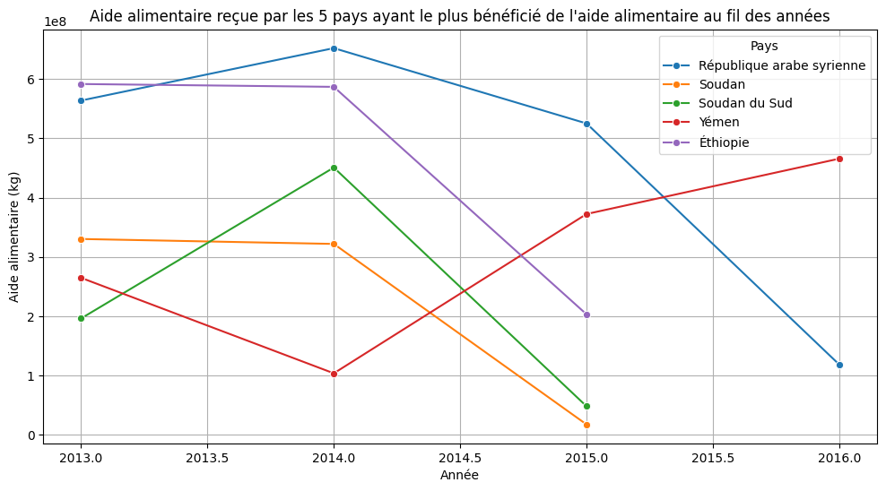

```python
# Affichage des pays avec l'aide alimentaire par année
plt.figure(figsize=(12, 6))
sns.lineplot(data=aide_alimentaire_top_5, x='Année', y='Valeur', hue='Zone', marker='o')
plt.title("Aide alimentaire reçue par les 5 pays ayant le plus bénéficié de l'aide alimentaire au fil des années")
plt.xlabel("Année")
plt.ylabel("Aide alimentaire (kg)")
plt.legend(title='Pays')
plt.grid()
plt.show()
```

### 3.9 - Pays avec le moins de disponibilité par habitant

```python
#Calcul de la disponibilité en kcal par personne par jour par pays
dispo_par_pays = dispo_alimentaire.groupby('Zone')['Disponibilité alimentaire (Kcal/personne/jour)'].sum().reset_index()
dispo_par_pays = dispo_par_pays.rename(columns={'Disponibilité alimentaire (Kcal/personne/jour)': 'Dispo_kcal_pers_jour'})
```

```python
#Affichage des 10 pays qui ont le moins de dispo alimentaire par personne
bottom_10 = dispo_par_pays.sort_values('Dispo_kcal_pers_jour').head(10)
print("10 pays avec le moins de disponibilité alimentaire par habitant (kcal/pers/jour) :")
display(bottom_10)
```

```
10 pays avec le moins de disponibilité alimentaire par habitant (kcal/pers/jour) :
```

|  | Zone | Dispo_kcal_pers_jour |
| --- | --- | --- |
| 128 | République centrafricaine | 1879.0 |
| 166 | Zambie | 1924.0 |
| 91 | Madagascar | 2056.0 |
| 0 | Afghanistan | 2087.0 |
| 65 | Haïti | 2089.0 |
| 133 | République populaire démocratique de Corée | 2093.0 |
| 151 | Tchad | 2109.0 |
| 167 | Zimbabwe | 2113.0 |
| 114 | Ouganda | 2126.0 |
| 172 | Éthiopie | 2129.0 |

### 3.10 - Pays avec le plus de disponibilité par habitant

```python
#Affichage des 10 pays qui ont le plus de dispo alimentaire par personne
top_10 = dispo_par_pays.sort_values('Dispo_kcal_pers_jour', ascending=False).head(10)
print("10 pays avec le plus de disponibilité alimentaire par habitant (kcal/pers/jour) :")
display(top_10)
```

```
10 pays avec le plus de disponibilité alimentaire par habitant (kcal/pers/jour) :
```

|  | Zone | Dispo_kcal_pers_jour |
| --- | --- | --- |
| 11 | Autriche | 3770.0 |
| 16 | Belgique | 3737.0 |
| 159 | Turquie | 3708.0 |
| 171 | États-Unis d'Amérique | 3682.0 |
| 74 | Israël | 3610.0 |
| 72 | Irlande | 3602.0 |
| 75 | Italie | 3578.0 |
| 89 | Luxembourg | 3540.0 |
| 168 | Égypte | 3518.0 |
| 4 | Allemagne | 3503.0 |

### 3.11 - Exemple de la Thaïlande pour le Manioc

```python
#création d'un dataframe avec uniquement la Thaïlande
thailande = dispo_alimentaire[dispo_alimentaire['Zone'] == 'Thaïlande']
```

```python
#Calcul de la sous nutrition en Thaïlande
# (Utilise l'intervalle 2016-2018 pour approx 2017, comme pour les autres questions)
sous_nut_thai = sous_nutrition[(sous_nutrition['Année'] == '2016-2018') & (sous_nutrition['Zone'] == 'Thaïlande')]
pop_thai = population[(population['Année'] == 2017) & (population['Zone'] == 'Thaïlande')]['Population'].values[0]
nb_sous_nut_thai = sous_nut_thai['sous_nutrition'].values[0]
print("Le nombre de personnes en état de sous nutrition en Thaïlande en 2017 est de :", nb_sous_nut_thai)
prop_sous_nut_thai = (nb_sous_nut_thai / pop_thai) * 100
print("En Thaïlande, la proportion de personnes en état de sous nutrition en 2017 est de : {:.2f}%".format(prop_sous_nut_thai))
```

```
Le nombre de personnes en état de sous nutrition en Thaïlande en 2017 est de : 6200000.0
En Thaïlande, la proportion de personnes en état de sous nutrition en 2017 est de : 8.96%
```

```python
# On calcule la proportion exportée en fonction de la proportion
manioc_thai = thailande[thailande['Produit'] == 'Manioc']
prop_export_manioc = (manioc_thai['Exportations - Quantité'].values[0] / manioc_thai['Production'].values[0]) * 100 if manioc_thai['Production'].values[0] > 0 else 0
print("En Thaïlande, la proportion de manioc exportée est de : {:.2f}%".format(prop_export_manioc))
```

```
En Thaïlande, la proportion de manioc exportée est de : 83.41%
```

## Etape 6 - Analyse complémentaires

```
Analyse complémentaire 1 : Top 10 pays avec le plus de disponibilité en protéines (g/pers/jour) :
```

|  | Zone | Dispo_prot_g_pers_jour |
| --- | --- | --- |
| 73 | Islande | 133.06 |
| 33 | Chine - RAS de Hong-Kong | 129.07 |
| 74 | Israël | 128.00 |
| 88 | Lituanie | 124.36 |
| 94 | Maldives | 122.32 |
| 52 | Finlande | 117.56 |
| 89 | Luxembourg | 113.64 |
| 102 | Monténégro | 111.90 |
| 119 | Pays-Bas | 111.46 |
| 2 | Albanie | 111.37 |

```
Bottom 10 pays avec le moins de disponibilité en protéines (g/pers/jour) :
```

|  | Zone | Dispo_prot_g_pers_jour |
| --- | --- | --- |
| 87 | Libéria | 37.66 |
| 62 | Guinée-Bissau | 44.05 |
| 103 | Mozambique | 45.68 |
| 128 | République centrafricaine | 46.04 |
| 91 | Madagascar | 46.69 |
| 65 | Haïti | 47.70 |
| 167 | Zimbabwe | 48.32 |
| 39 | Congo | 51.41 |
| 114 | Ouganda | 52.64 |
| 139 | Sao Tomé-et-Principe | 53.10 |

```
Analyse complémentaire 2 : Top 10 pays aidés vs. sous-nutrition (aide en tonnes) :
```

|  | Zone | Valeur | sous_nutrition |
| --- | --- | --- | --- |
| 50 | République arabe syrienne | 1858943000 | 0.0 |
| 74 | Éthiopie | 1381294000 | 21100000.0 |
| 69 | Yémen | 1206484000 | 0.0 |
| 61 | Soudan du Sud | 695248000 | 0.0 |
| 60 | Soudan | 669784000 | 5000000.0 |
| 30 | Kenya | 552836000 | 11900000.0 |
| 3 | Bangladesh | 348188000 | 21500000.0 |
| 59 | Somalie | 292678000 | 0.0 |
| 53 | République démocratique du Congo | 288502000 | 0.0 |
| 43 | Niger | 276344000 | 0.0 |

```
Analyse complémentaire 3 : Pertes alimentaires totales mondiales :
453,698,000 tonnes (soit environ 4.6% de la disponibilité intérieure)
```

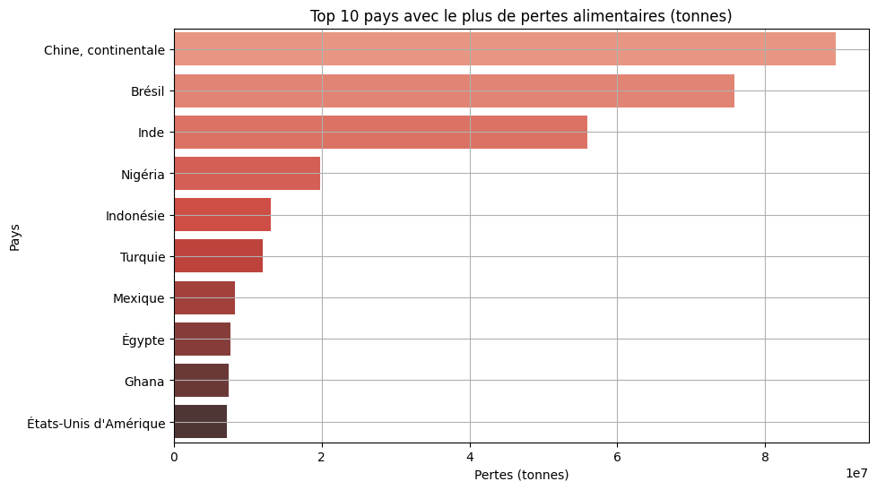

```python
#ajouter en dessous toutes les analyses complémtaires


# 1. Disponibilité en protéines : top 10 max/min (similaire à kcal)
dispo_prot_par_pays = dispo_alimentaire.groupby('Zone')['Disponibilité de protéines en quantité (g/personne/jour)'].sum().reset_index()
dispo_prot_par_pays = dispo_prot_par_pays.rename(columns={'Disponibilité de protéines en quantité (g/personne/jour)': 'Dispo_prot_g_pers_jour'})

top_10_prot = dispo_prot_par_pays.sort_values('Dispo_prot_g_pers_jour', ascending=False).head(10)
bottom_10_prot = dispo_prot_par_pays.sort_values('Dispo_prot_g_pers_jour').head(10)

print("Analyse complémentaire 1 : Top 10 pays avec le plus de disponibilité en protéines (g/pers/jour) :")
display(top_10_prot)

print("Bottom 10 pays avec le moins de disponibilité en protéines (g/pers/jour) :")
display(bottom_10_prot)

# 2. Corrélation aide alimentaire totale (2013-2016) et sous-nutrition (2017)
aide_totale = aide_alimentaire.groupby('Zone')['Valeur'].sum().reset_index()
sous_nut_2017 = sous_nutrition[sous_nutrition['Année'] == '2016-2018'][['Zone', 'sous_nutrition']]
corr_aide_sousnut = aide_totale.merge(sous_nut_2017, on='Zone', how='inner').sort_values('Valeur', ascending=False).head(10)

print("\nAnalyse complémentaire 2 : Top 10 pays aidés vs. sous-nutrition (aide en tonnes) :")
display(corr_aide_sousnut)

# 3. Pertes totales mondiales
pertes_totales = dispo_alimentaire['Pertes'].sum()

print("\nAnalyse complémentaire 3 : Pertes alimentaires totales mondiales :")
print(f"{pertes_totales:,.0f} tonnes (soit environ 4.6% de la disponibilité intérieure)")

# 4. Optionnel : Graphique simple (ex. barplot top 10 pertes par pays)
pertes_par_pays = dispo_alimentaire.groupby('Zone')['Pertes'].sum().sort_values(ascending=False).head(10)
plt.figure(figsize=(10,6))
sns.barplot(x=pertes_par_pays.values, y=pertes_par_pays.index, hue=pertes_par_pays.index, palette='Reds_d', legend=False)
plt.title('Top 10 pays avec le plus de pertes alimentaires (tonnes)')
plt.xlabel('Pertes (tonnes)')
plt.ylabel('Pays')
plt.grid()
plt.show()
```